# Alcohol Beverage Services (ABS)

```r
cor(store_demo$TotalSales, store_demo$TotalPopulation, use = "complete.obs")
```

```
## [1] 0.0928748
```

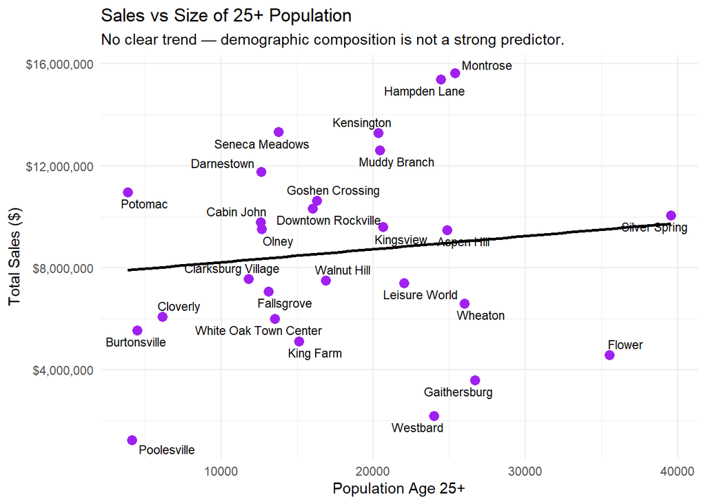

```r
# Sales vs 25+ population

ggplot(store_demo,
       aes(x = Older25Years, y = TotalSales)) +
  geom_point(size = 3, color = "purple") +
  geom_smooth(method = "lm", se = FALSE, color = "black") +
  ggrepel::geom_text_repel(
    aes(label = STORENAME),
    size          = 3,
    max.overlaps  = 100,
    segment.color = "grey70",
    show.legend   = FALSE
  ) +
labs(
    title = "Sales vs Size of 25+ Population",
    x     = "Population Age 25+",
    y     = "Total Sales ($)",
    subtitle = "No clear trend — demographic composition is not a strong predictor."
  ) +
  scale_y_continuous(labels = dollar) +
  theme_minimal()
```

```r
cor(store_demo$TotalSales, store_demo$Older25Years, use = "complete.obs")
```

```
## [1] 0.1209889
```

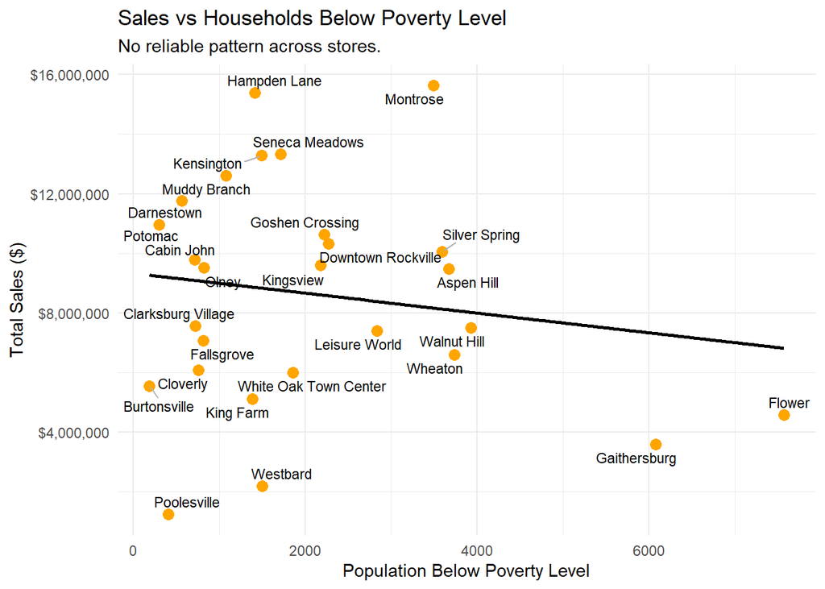

```r
ggplot(store_demo,
       aes(x = PovertyLevel,
           y = TotalSales)) +
  geom_point(size = 3, color = "orange") +
  geom_smooth(method = "lm", se = FALSE, color = "black") +
  ggrepel::geom_text_repel(
    aes(label = STORENAME),
    size          = 3,
    max.overlaps  = 100,
    segment.color = "grey70",
    show.legend   = FALSE
  ) +
  labs(
    title = "Sales vs Households Below Poverty Level",
    x     = "Population Below Poverty Level",
    y     = "Total Sales ($)",
    subtitle = "No reliable pattern across stores."
  ) +
  scale_y_continuous(labels = dollar) +
  theme_minimal()
```

```r
cor(store_demo$TotalSales, store_demo$PovertyLevel, use = "complete.obs")
```

```
## [1] -0.1579369
```

# 15. Quadrant Analyses (Sales vs Traffic vs Baskets per SqFt)

To diagnose relative store performance across multiple dimensions simultaneously, quadrant analyses are conducted using normalized store-level key performance indicators. Sales efficiency, traffic efficiency, and basket density are measured on a per–square-foot basis to ensure comparability across stores of different sizes. Median values are used as cutoffs to classify stores into high and low performance groups across paired dimensions. These quadrant visualizations provide an intuitive framework for identifying over- and under-performing stores and for distinguishing whether performance differences are driven primarily by traffic volume, basket behavior, or sales efficiency.

```r
# Build final store-level dataset with KPIs, demographics, and mix
store_final <- store_summary %>%
  left_join(demographics_selected, by = "STORENAME") %>%
  left_join(store_category_mix, by = "STORENAME") %>%
  left_join(store_daytype_mix,   by = "STORENAME") %>%
  mutate(
    TotalSalesPerSqFt        = TotalSales / SquareFootage,
    TotalTransactionsPerSqFt = TotalTransactions / SquareFootage,
    TotalBasketsPerSqFt      = TotalBaskets / SquareFootage,
    Avg_BasketValue          = TotalSales / TotalBaskets
  ) %>%
  distinct(STORENAME, .keep_all = TRUE) %>%
  relocate(SquareFootage, TotalPopulation, .after = STORENAME)

# Check for duplicate store rows (should be none)
store_final %>%
  count(STORENAME) %>%
  filter(n > 1)
```

```
## # A tibble: 0 × 2
## # ℹ 2 variables: STORENAME <chr>, n <int>
```

```r
# Median cutoffs for quadrants
med_sales_per_sqft <- median(store_final$TotalSalesPerSqFt,        na.rm = TRUE)
med_trans_per_sqft <- median(store_final$TotalTransactionsPerSqFt, na.rm = TRUE)
med_bask_per_sqft  <- median(store_final$TotalBasketsPerSqFt,      na.rm = TRUE)

# Assign quadrant labels for different KPI pairings
store_quadrant <- store_final %>%
  mutate(
    Quad_SalesTraffic = case_when(
      TotalSalesPerSqFt        >= med_sales_per_sqft &
        TotalTransactionsPerSqFt >= med_trans_per_sqft ~ "High Spend & High Traffic",
      TotalSalesPerSqFt        >= med_sales_per_sqft &
        TotalTransactionsPerSqFt <  med_trans_per_sqft ~ "High Spend & Low Traffic",
      TotalSalesPerSqFt        <  med_sales_per_sqft &
        TotalTransactionsPerSqFt >= med_trans_per_sqft ~ "Low Spend & High Traffic",
      TRUE ~ "Low Spend & Low Traffic"
    ),
    Quad_SalesBaskets = case_when(
      TotalSalesPerSqFt     >= med_sales_per_sqft &
        TotalBasketsPerSqFt >= med_bask_per_sqft ~ "High Spend & High Baskets",
      TotalSalesPerSqFt     >= med_sales_per_sqft &
        TotalBasketsPerSqFt <  med_bask_per_sqft ~ "High Spend & Low Baskets",
      TotalSalesPerSqFt     <  med_sales_per_sqft &
        TotalBasketsPerSqFt >= med_bask_per_sqft ~ "Low Spend & High Baskets",
      TRUE ~ "Low Spend & Low Baskets"
    ),
    Quad_TrafficBaskets = case_when(
      TotalTransactionsPerSqFt >= med_trans_per_sqft &
        TotalBasketsPerSqFt    >= med_bask_per_sqft ~ "High Traffic & High Baskets",
      TotalTransactionsPerSqFt >= med_trans_per_sqft &
        TotalBasketsPerSqFt    <  med_bask_per_sqft ~ "High Traffic & Low Baskets",
      TotalTransactionsPerSqFt <  med_trans_per_sqft &
        TotalBasketsPerSqFt    >= med_bask_per_sqft ~ "Low Traffic & High Baskets",
      TRUE ~ "Low Traffic & Low Baskets"
    )
  )
```

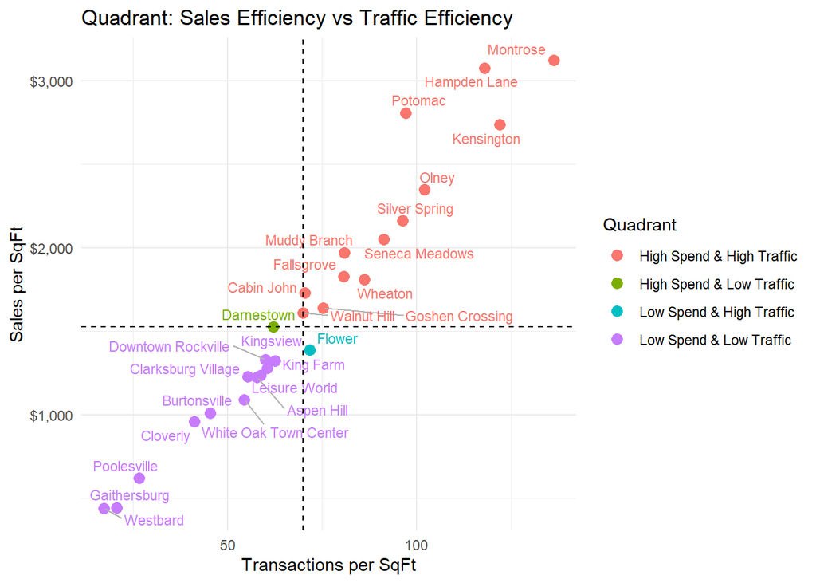

```r
# Quadrant plot: Sales per SqFt vs Transactions per SqFt
ggplot(store_quadrant,
       aes(x = TotalTransactionsPerSqFt,
           y = TotalSalesPerSqFt,
           color = Quad_SalesTraffic)) +
  geom_point(size = 3) +
  ggrepel::geom_text_repel(
    aes(label = STORENAME),
    size          = 3,
    max.overlaps  = 100,
    segment.color = "grey70",
    show.legend   = FALSE
  ) +
  geom_vline(xintercept = med_trans_per_sqft, linetype = "dashed") +
  geom_hline(yintercept = med_sales_per_sqft,  linetype = "dashed") +
  labs(
    title = "Quadrant: Sales Efficiency vs Traffic Efficiency",
    x     = "Transactions per SqFt",
    y     = "Sales per SqFt",
    color = "Quadrant"
  ) +
  scale_y_continuous(labels = dollar) +
  theme_minimal()
```

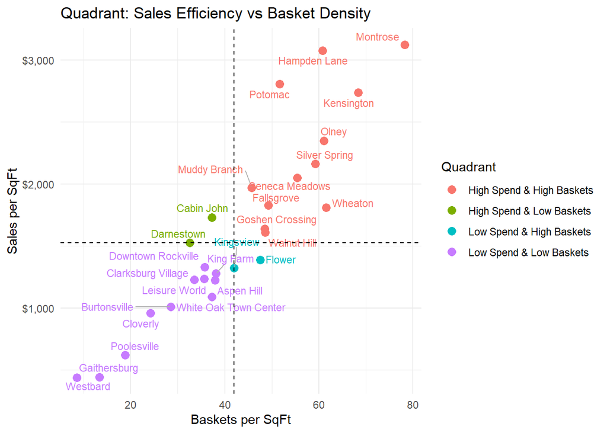

```r
# Quadrant plot: Sales per SqFt vs Baskets per SqFt
ggplot(store_quadrant,
       aes(x = TotalBasketsPerSqFt,
           y = TotalSalesPerSqFt,
           color = Quad_SalesBaskets)) +
  geom_point(size = 3) +
  ggrepel::geom_text_repel(
    aes(label = STORENAME),
    size          = 3,
    max.overlaps  = 100,
    segment.color = "grey70",
    show.legend   = FALSE
  ) +
  geom_vline(xintercept = med_bask_per_sqft, linetype = "dashed") +
  geom_hline(yintercept = med_sales_per_sqft, linetype = "dashed") +
  labs(
    title = "Quadrant: Sales Efficiency vs Basket Density",
    x     = "Baskets per SqFt",
    y     = "Sales per SqFt",
    color = "Quadrant"
  ) +
  scale_y_continuous(labels = dollar) +
  theme_minimal()
```

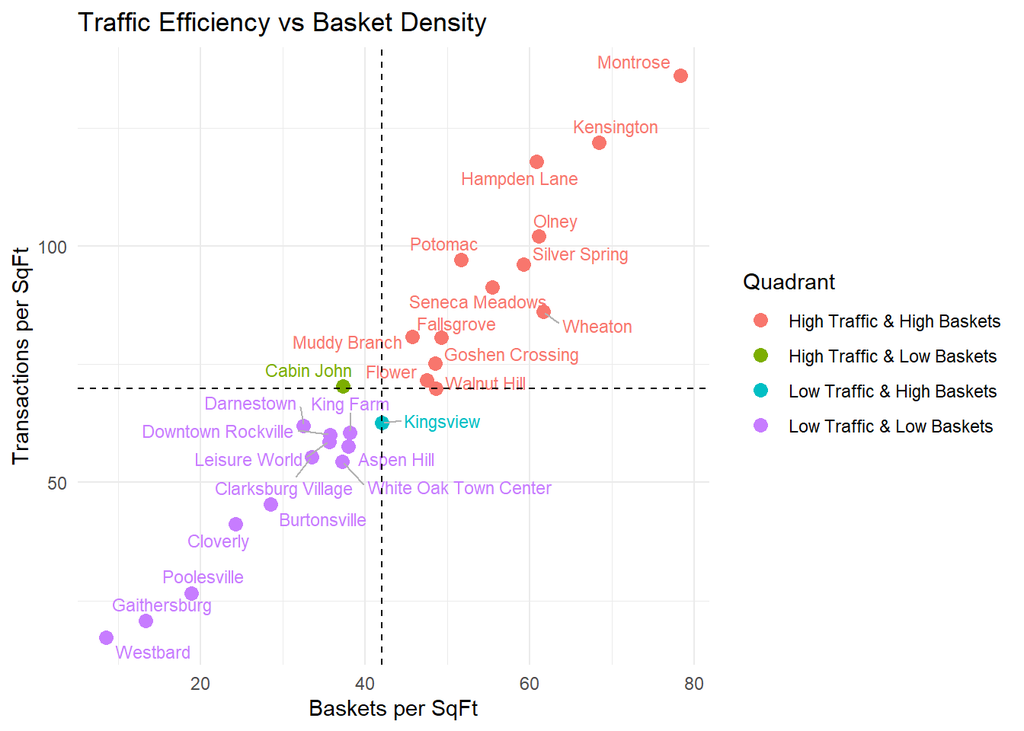

```r
# Quadrant plot: Transactions per SqFt vs Baskets per SqFt
ggplot(store_quadrant,
       aes(x = TotalBasketsPerSqFt,
           y = TotalTransactionsPerSqFt,
           color = Quad_TrafficBaskets)) +
  geom_point(size = 3) +
  ggrepel::geom_text_repel(
    aes(label = STORENAME),
    size          = 3,
    max.overlaps  = 100,
    segment.color = "grey70",
    show.legend   = FALSE
  ) +
  geom_vline(xintercept = med_bask_per_sqft,  linetype = "dashed") +
  geom_hline(yintercept = med_trans_per_sqft, linetype = "dashed") +
  labs(
    title = "Traffic Efficiency vs Basket Density",
    x     = "Baskets per SqFt",
    y     = "Transactions per SqFt",
    color = "Quadrant"
  ) +
  theme_minimal()
```

# Interpretation: Store Performance Quadrants

The quadrant analyses reveal meaningful heterogeneity in store performance across sales efficiency, traffic intensity, and basket density. Some stores achieve high sales primarily through strong traffic, while others rely on higher basket value or transaction density. The dispersion across quadrants indicates that under- and over-performance can arise from different underlying mechanisms, reinforcing the need to evaluate stores along multiple dimensions rather than relying on a single performance metric.

# 16. Store-Level Performance Drivers (Model Results)

This section investigates the drivers of store-level sales performance using multivariate regression models. To enable fair comparison across stores of different sizes, sales performance is measured as sales per square foot, and a logarithmic transformation is applied to stabilize variance and reduce the influence of extreme values. The modeling dataset is constructed at the store level, incorporating operational metrics, basket characteristics, category mix, temporal mix, and selected demographic variables.

Two complementary modeling approaches are used. First, an ordinary least squares (OLS) regression is estimated to provide interpretable coefficient estimates and statistical significance measures. Second, an Elastic Net regression is applied to address potential multicollinearity among predictors and to assess the robustness of results under regularization. Both models use the same predictor set to ensure comparability.

Model diagnostics are then examined using predicted versus actual values, residual distributions, and residual plots. These diagnostics assess overall fit, identify systematic patterns, and highlight stores that perform substantially above or below model expectations. Residual-based rankings are used to distinguish over- and under-performing stores after controlling for observable characteristics, providing a structured framework for identifying performance differences not explained by size, traffic, or market context.

```r
# Build modeling dataset (one row per store)
model_data <- store_final %>%
  filter(
    !is.na(SquareFootage), SquareFootage > 0,
    !is.na(TotalSalesPerSqFt), TotalSalesPerSqFt > 0
  ) %>%
  mutate(
    SalesPerSqFt     = TotalSalesPerSqFt,
    log_SalesPerSqFt = log(SalesPerSqFt)
  ) %>%
  select(
    STORENAME,
    SalesPerSqFt,
    log_SalesPerSqFt,
    SquareFootage,
    TotalPopulation,
    Older25Years,
    PovertyLevel,
    Avg_BasketValue,
    AvgItemsPerBasket,
    TotalTransactionsPerSqFt,
    Share_BEER,
    Share_LIQ,
    Share_WINE,
    Share_Weekday,
    Share_Weekend
  ) %>%
  tidyr::drop_na()

# Basic sanity checks
nrow(model_data)
```

```
## [1] 27
```

```r
str(model_data)
```

```
## tibble [27 × 15] (S3: tbl_df/tbl/data.frame)
##  $ STORENAME               : chr [1:27] "Aspen Hill" "Burtonsville" "Cabin John" "Clarksburg Village" ...
##  $ SalesPerSqFt            : num [1:27] 1223 1011 1730 1228 958 ...
##  $ log_SalesPerSqFt        : num [1:27] 7.11 6.92 7.46 7.11 6.86 ...
##  $ SquareFootage           : num [1:27] 7748 5500 5660 6163 6350 ...
##  $ TotalPopulation         : num [1:27] 37572 6478 18098 18185 8890 ...
##  $ Older25Years            : num [1:27] 24844 4479 12593 11796 6162 ...
##  $ PovertyLevel            : num [1:27] 3670 185 715 721 752 ...
##  $ Avg_BasketValue         : num [1:27] 32.2 35.5 46.4 36.6 39.6 ...
##  $ AvgItemsPerBasket       : num [1:27] 2.09 2.21 2.56 2.19 2.36 ...
##  $ TotalTransactionsPerSqFt: num [1:27] 57.7 45.5 70.4 55.4 41.2 ...
##  $ Share_BEER              : num [1:27] 0.0919 0.0725 0.0651 0.0773 0.057 ...
##  $ Share_LIQ               : num [1:27] 0.698 0.632 0.554 0.618 0.67 ...
##  $ Share_WINE              : num [1:27] 0.203 0.288 0.37 0.297 0.266 ...
##  $ Share_Weekday           : num [1:27] 0.633 0.691 0.686 0.674 0.686 ...
##  $ Share_Weekend           : num [1:27] 0.361 0.302 0.308 0.32 0.308 ...
```

```r
summary(model_data$SalesPerSqFt)
```

```
##    Min. 1st Qu.  Median    Mean 3rd Qu.    Max.
##   439.9  1225.5  1524.8  1629.1  2010.0  3125.4
```

# Interpretation: Modeling Dataset Construction

The final modeling dataset consists of 27 stores with complete and internally consistent measurements across operational, compositional, and demographic dimensions. The log transformation of sales per square foot reduces skewness and stabilizes variance, improving the suitability of linear modeling. Given the ratio of predictors to observations, the dataset supports explanatory analysis and relative ranking but requires cautious interpretation of coefficient magnitude and significance.

```r
# Predictor set for both OLS and Elastic Net
predictors <- c(
  "SquareFootage",
  "TotalPopulation",
  "Older25Years",
  "PovertyLevel",
  "Avg_BasketValue",
  "AvgItemsPerBasket",
  "TotalTransactionsPerSqFt",
  "Share_BEER",
  "Share_LIQ",
  "Share_WINE",
  "Share_Weekday",
  "Share_Weekend"
)

# Formula on log scale
model_formula <- as.formula(
  paste("log_SalesPerSqFt ~", paste(predictors, collapse = " + "))
)

model_formula
```

```
## log_SalesPerSqFt ~ SquareFootage + TotalPopulation + Older25Years +
##     PovertyLevel + Avg_BasketValue + AvgItemsPerBasket + TotalTransactionsPerSqFt +
##     Share_BEER + Share_LIQ + Share_WINE + Share_Weekday + Share_Weekend
```

```r
# Fit OLS model
lm_model <- lm(model_formula, data = model_data)
summary(lm_model)
```

```
##
## Call:
## lm(formula = model_formula, data = model_data)
##
## Residuals:
##      Min       1Q   Median       3Q      Max
## -0.15501 -0.05167  0.01520  0.05135  0.18978
##
## Coefficients:
##                            Estimate Std. Error t value Pr(>|t|)
## (Intercept)               2.796e+01  4.198e+01   0.666  0.51616
## SquareFootage             1.632e-05  1.986e-05   0.822  0.42497
## TotalPopulation           2.411e-05  3.004e-05   0.802  0.43577
## Older25Years             -3.104e-05  3.924e-05  -0.791  0.44211
## PovertyLevel             -1.621e-05  3.163e-05  -0.513  0.61626
## Avg_BasketValue           2.041e-02  1.012e-02   2.016  0.06342 .
## AvgItemsPerBasket        -2.195e-01  2.440e-01  -0.900  0.38351
## TotalTransactionsPerSqFt  1.607e-02  9.151e-04  17.565  6.2e-11 ***
## Share_BEER                5.682e+01  1.914e+01   2.968  0.01017 *
## Share_LIQ                 5.569e+01  1.845e+01   3.019  0.00920 **
## Share_WINE                5.566e+01  1.808e+01   3.079  0.00817 **
## Share_Weekday            -7.674e+01  3.565e+01  -2.153  0.04928 *
## Share_Weekend            -8.051e+01  3.600e+01  -2.236  0.04212 *
## ---
## Signif. codes:  0 '***' 0.001 '**' 0.01 '*' 0.05 '.' 0.1 ' ' 1
##
## Residual standard error: 0.1092 on 14 degrees of freedom
## Multiple R-squared:  0.9756, Adjusted R-squared:  0.9546
## F-statistic: 46.57 on 12 and 14 DF,  p-value: 3.703e-09
```

# Drivers of Sales per Square Foot

The store-level OLS model explains variation in log-transformed Sales per Square Foot as a function of store size, local demographics, basket characteristics, traffic intensity, temporal mix, and category mix. With an adjusted R² of approximately 0.96, the model captures the majority of cross-store differences in sales productivity across the 27-store system.

The dominant driver of sales productivity is traffic intensity. TotalTransactionsPerSqFt is highly statistically significant (p < 1e-10) and exhibits the largest practical effect size, indicating that stores processing more transactions per unit of space consistently generate higher sales per square foot. This result is robust across model specifications and persists under penalized regression.

Category mix also contributes meaningfully to performance. The revenue shares of Beer, Liquor, and Wine are all positively associated with Sales per SqFt relative to the omitted Miscellaneous category. Because category shares sum to one, these coefficients should be interpreted as contrasts rather than independent levers. Stores whose revenue is concentrated in core alcohol categories tend to use their selling space more productively than stores with heavier miscellaneous sales.

Basket value plays a secondary role. Average basket value has a positive but borderline-significant association (p ≈ 0.06), suggesting that increasing spend per visit can improve productivity, but its effect is weaker than that of traffic or category mix.

Demographics and store size function primarily as controls rather than drivers. Square footage, total population, age composition, and poverty level do not exhibit strong independent effects once traffic and mix are accounted for. Within this relatively homogeneous county system, operational factors dominate structural ones.

Given the small sample size relative to the number of predictors, this model should be interpreted as descriptive and diagnostic rather than predictive. Its primary value lies in ranking drivers, benchmarking stores against modeled expectations, and identifying relative over- and under-performance.

```r
# Rank OLS coefficients by magnitude
lm_tidy <- broom::tidy(lm_model) %>%
  dplyr::filter(term != "(Intercept)") %>%
  dplyr::arrange(desc(abs(estimate)))
lm_tidy
```

```
## # A tibble: 12 × 5
##    term                        estimate  std.error statistic  p.value
##    <chr>                          <dbl>      <dbl>     <dbl>    <dbl>
##  1 Share_Weekend            -80.5       36.0          -2.24  4.21e- 2
##  2 Share_Weekday            -76.7       35.7          -2.15  4.93e- 2
##  3 Share_BEER                56.8       19.1           2.97  1.02e- 2
##  4 Share_LIQ                 55.7       18.4           3.02  9.20e- 3
##  5 Share_WINE                55.7       18.1           3.08  8.17e- 3
##  6 AvgItemsPerBasket         -0.220      0.244        -0.900 3.84e- 1
##  7 Avg_BasketValue            0.0204     0.0101        2.02  6.34e- 2
##  8 TotalTransactionsPerSqFt   0.0161     0.000915     17.6   6.20e-11
##  9 Older25Years              -0.0000310  0.0000392    -0.791 4.42e- 1
## 10 TotalPopulation            0.0000241  0.0000300     0.802 4.36e- 1
## 11 SquareFootage              0.0000163  0.0000199     0.822 4.25e- 1
## 12 PovertyLevel              -0.0000162  0.0000316    -0.513 6.16e- 1
```

```r
# Matrix X and response y for glmnet
x <- model_data %>%
  dplyr::select(all_of(predictors)) %>%
  as.matrix()

y <- model_data$log_SalesPerSqFt

set.seed(123)

# LOOCV Elastic Net to select lambda
cv_fit <- cv.glmnet(
  x, y,
  alpha       = 0.5,
  nfolds      = nrow(model_data),
  standardize = TRUE
)
best_lambda <- cv_fit$lambda.1se
best_lambda
```

```
## [1] 0.149597
```

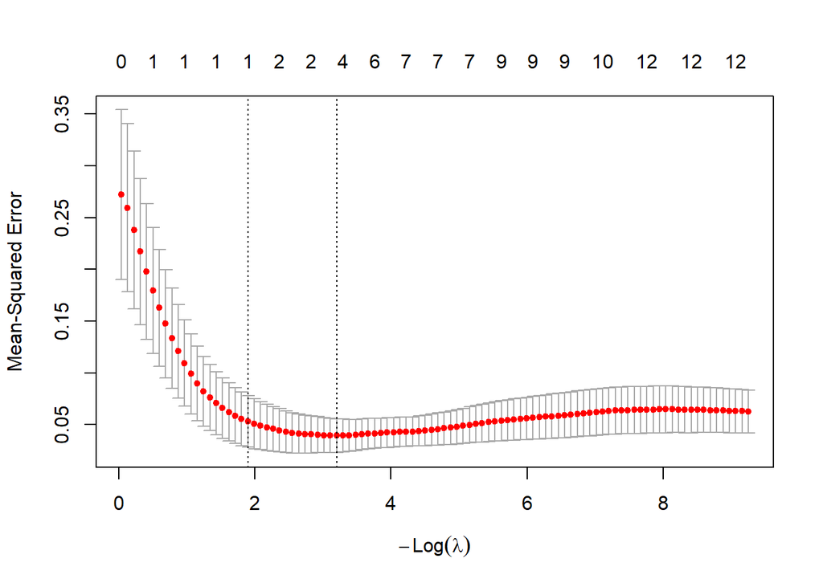

```r
plot(cv_fit)
```

```r
# Fit Elastic Net at selected lambda
enet_model <- glmnet(
  x, y,
  alpha       = 0.5,
  lambda      = best_lambda,
  standardize = TRUE
)

coef(enet_model)
```

```
## 13 x 1 sparse Matrix of class "dgCMatrix"
##                                  s0
## (Intercept)              6.40934930
## SquareFootage            .
## TotalPopulation          .
## Older25Years             .
## PovertyLevel             .
## Avg_BasketValue          .
## AvgItemsPerBasket        .
## TotalTransactionsPerSqFt 0.01229276
## Share_BEER               .
## Share_LIQ                .
## Share_WINE               .
## Share_Weekday            .
## Share_Weekend            .
```